# Markov

Mikolaj Biesaga

Tak jak pisałem w mailu. Najpierw zacząłem od najprostrzych rzeczy. Trochę, żeby podiagnozować te dane, tzn. co ewentualnie można zobaczyć w nich na pierwszy rzut oka. Poza tym niektóre z tych pierwszych funkcji potem mi się przydadzą.

## 1. Wczytanie danych i wstępna obróbka

Na razie wziąłem dwa ciągi, które pi razy drzwi składają się z 300 elementów. O tyle ma to znaczenie, że podejrzewam, że te funkcje mocno zwolnią na dłużyszych ciągach. Próbowałem na ciągu składającym się ze 100 tysięcy elementów i najszybsza z nich czyli dla historii 1 zwolniła 1000 razy. Z ważnych rzeczy to przyjąłem, że odstęp między 1 liczę w liczbie zer pomiędzy dwoma jednynkami, tzn. między 1,1 odstęp jest zero. W jakimś stopniu jest to oczywiste ale na wszelki wypadek zaznaczam.

```r
load("~/Desktop/Biologia_kwantowa/Biologia_kwantowa.RData")
library(readr)
library(plyr)
library(gtools)
library(ggplot2)

example_1 <- read_csv("~/Desktop/Psychologia kwantowa/Survey/los_chem_zera_3_3_10_57_34.csv")
example_2 <- read_csv("~/Desktop/Psychologia kwantowa/Survey/los_chem_zera_3_1_14_17_18.csv")

#tworznie ciągu odstępu między jedynkami
example_1_rows_with_1 <- with(example_1,key==1)
example_2_rows_with_1 <- with(example_2,key==1)
breaks_example_1 <- example_1[example_1_rows_with_1,]
breaks_example_2 <- example_2[example_2_rows_with_1,]
breaks_example_1$gap <- c(NA,(breaks_example_1[2:nrow(breaks_example_1),1]-breaks_example_1[1:nrow(breaks_example_1)-1,1])$id)-1
breaks_example_2$gap <- c(NA,(breaks_example_2[2:nrow(breaks_example_2),1]-breaks_example_2[1:nrow(breaks_example_2)-1,1])$id)-1
#przydatne do wykresów bo bez pierwszego wiersza, w którym w normalnym zbiorze jest NA bo nie wiadomo kiedy było ostatnia 1.
breaks_example_1_chart <- breaks_example_1[-1,]
breaks_example_2_chart <- breaks_example_2[-1,]
```

## 2. Wstępna diagnostyka (głównie wykresy)

Poniżej znadują się wykresy, które pokazują jak się zmieniają długości odstępów w obu ciągach. Czerwona linia to mediana (wydała mi się ciekawsza niż średnia), a niebieskie to odchyelnia standardow. Ostatni wykres to CrossCorralation pierwszego ciągu z drugim +/- lag. Moim zdaniem przynajmniej na tych przykładach nic specjalnie ciekawego nie widac. Poza tym, że w danych z neuronów spodziewam się, że jednak odstępy będą większe.

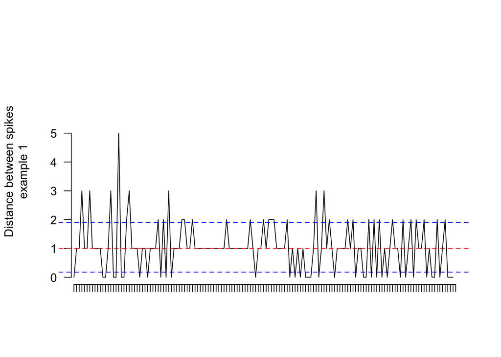

```r
par(las=1)
#ustalenie długości osi x, żeby miały tę samą długość
x1 <- c(1:dim(breaks_example_1)[1])
x2 <- c(1:dim(breaks_example_2)[1])

if(length(x1)>length(x2)){
  x <- x1
}else{
  x <- x2
}
#mnożę razy 20 tylko dlatego, ze inaczej jest nieczytelne przy tak długiej osi x.
#nie ma legendy bo ciężko zrobic taką, która nie zasłoni całego wyrkesu
y1 <- c(0:max(breaks_example_1_chart$gap))*20
plot(x,type="n",xlab="",ylab="",axes=F)
title(ylab=strwrap("Distance between spikes example 1",30))
axis(2,pos=0,y1,labels=y1/20)
axis(1,pos=-5,x,labels=F)
lines(breaks_example_1_chart$gap*20)
abline(h=median(breaks_example_1_chart$gap)*20,col="red",lty="dashed")
abline(h=mean(breaks_example_1_chart$gap)*20-sd(breaks_example_1_chart$gap)*20,col="blue",lty="dashed")
abline(h=mean(breaks_example_1_chart$gap)*20+sd(breaks_example_1_chart$gap)*20,col="blue",lty="dashed")
```

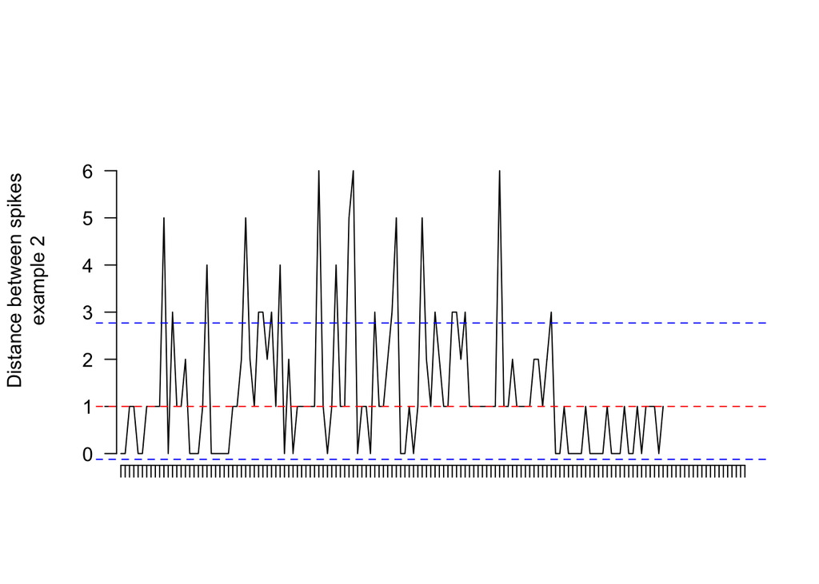

```r
#legend("topright", legend=c("Median", "Mean +/- SD"),lty="dashed", col=c("blue", "red"),cex=1,pt.lwd=0.25)

#Drugi wykres, drugiego ciągu
y2 <- c(0:max(breaks_example_2_chart$gap))*20
plot(x,type="n",xlab="",ylab="",axes=F)
title(ylab=strwrap("Distance between spikes example 2",30))
axis(2,pos=0,y2,2,labels=y2/20)
axis(1,pos=-5,x,labels=F)
lines(breaks_example_2_chart$gap*20)
abline(h=median(breaks_example_2_chart$gap)*20,col="red",lty="dashed")
abline(h=mean(breaks_example_2_chart$gap)*20-sd(breaks_example_2_chart$gap)*20,col="blue",lty="dashed")
abline(h=mean(breaks_example_2_chart$gap)*20+sd(breaks_example_2_chart$gap)*20,col="blue",lty="dashed")
```

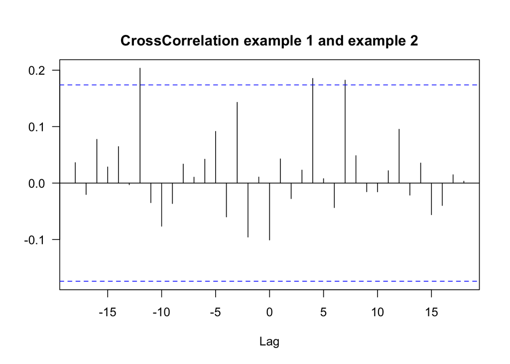

```r
#wykres kross korelacji pomędzy example 1, a example 2. Zasadniczo lag odnosi się do drugiego ciągu.
ccf(breaks_example_1_chart$gap,breaks_example_2_chart$gap,type = "correlation",ylab="",main="")
title(main="CrossCorrelation example 1 and example 2",line=1)
```

Tutaj rozkłady prawdopodobieństwa. Na tego typu wykresie będzie moim zdaniem wstępne różnice zaobserwować.

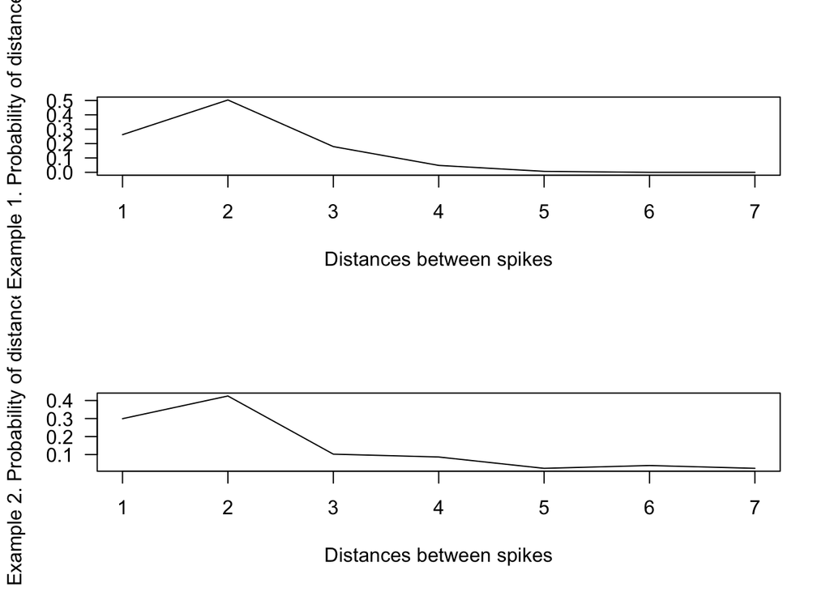

```r
#rozkłady prawdopodobieństwa poszczególnych
probability_distribution_example_1 <- as.vector(table(breaks_example_1_chart$gap)/length(breaks_example_1_chart$gap))
probability_distribution_example_2 <- as.vector(table(breaks_example_2_chart$gap)/length(breaks_example_2_chart$gap))

if(length(probability_distribution_example_1)>length(probability_distribution_example_2)){
  difference <- length(probability_distribution_example_1)-length(probability_distribution_example_2)
  probability_distribution_example_1 <- c(probability_distribution_example_1,rep(0,difference))
}else{
  difference <- length(probability_distribution_example_2)-length(probability_distribution_example_1)
  probability_distribution_example_1 <- c(probability_distribution_example_1,rep(0,difference))
}

par(mfrow=c(2,1),las=1)
plot(probability_distribution_example_1,type="n",xlab="",ylab="")
title(ylab="Example 1. Probability of distances",xlab = "Distances between spikes")
lines(probability_distribution_example_1)

plot(probability_distribution_example_2,type="n",xlab="",ylab="")
title(ylab="Example 2. Probability of distances",xlab = "Distances between spikes")
lines(probability_distribution_example_2)
```

# Klasyczne prawdopodobieństwo

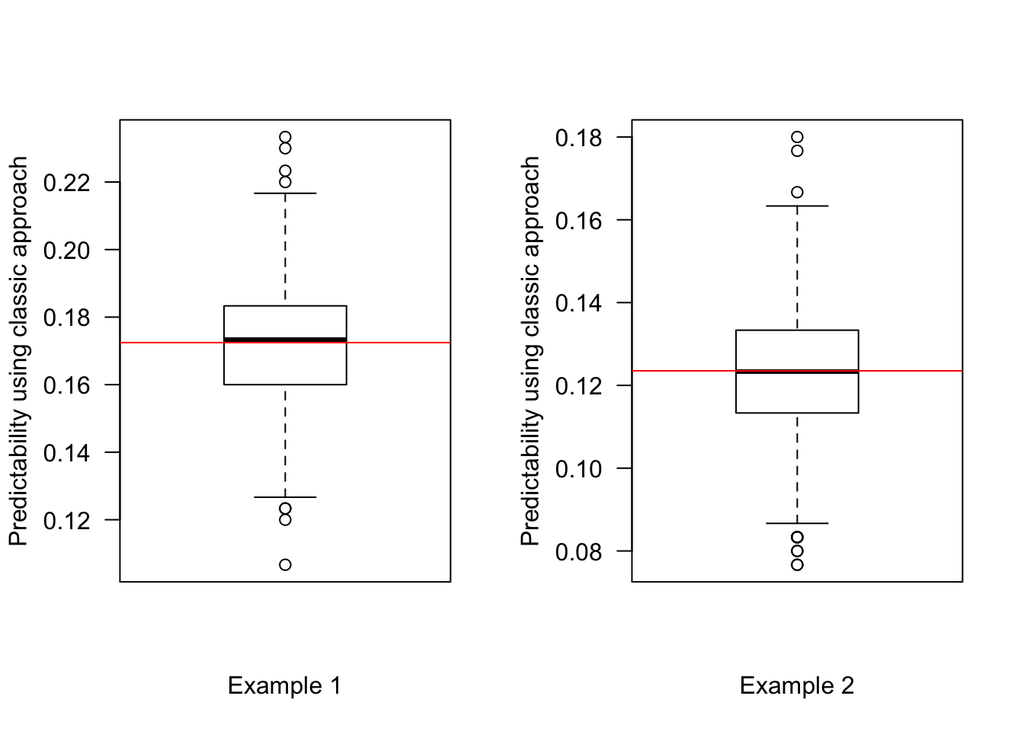

```r
#funkcja, która za pomocą klasycznego prawdopodobieństwa liczy 1000 prawdopodobieństw trafienia w nasz zwykły ciąg
#potrzebuje, tablei z gap oraz prawdopodobieństwo poszczególnych gapów.
classic_approach <- function(breaks_example,probability_distribution){
  wynik <- 0
  for(j in c(1:1000)){
    temp_wynik <- 0
    temp_wynik <- sample(sort(unique(breaks_example$gap)),length(breaks_example$gap),replace=T,probability_distribution[probability_distribution>0])
    wynik[j] <- (sum(breaks_example$gap==temp_wynik)/length(breaks_example))/100
  }
  return(wynik)
}

classic_approach_example_1 <- classic_approach(breaks_example_1_chart,probability_distribution_example_1)
classic_approach_example_2 <- classic_approach(breaks_example_2_chart,probability_distribution_example_2)


#czerwona linia to średnia, a czarna to oczywiście mediana. Dlatego lepiej brać medianę.
par(mfrow=c(1,2),las=1)
boxplot(classic_approach_example_1,xlab="",ylab="")
title(xlab = "Example 1",ylab="Predictability using classic approach")
abline(h=mean(classic_approach_example_1),col="red")
boxplot(classic_approach_example_2,xlab="",ylab="")
title(xlab = "Example 2",ylab="Predictability using classic approach")
abline(h=mean(classic_approach_example_2),col="red")
```

## 3. Pierwsze podejście do ukrytych ciągów Markova

# Funkcje

Ta funkcja przygotowuje indeksy. Zasadniczo chodzi o to, żeby podzielić ciąg odstępów na odcinki składające się, gdy historia ma być np. 1, z dwóch elementów. Odpowiednio dla historii n podział będzie na n-elementowych ciągów. Tzn. chodzi o to, żeby ciąg c(0,2,4,5,3,2), przy dwóch elementach na c(0,2,2,4,4,5,5,3,3,2)

```r
#funkcja, która przygtowuje wektor w taki sposób, że w zależności od długości historii
# zamienia np. przy historii 1 wektor c(1,2,3) na c(1,2,2,3)
#możliwe ulepszenie to oczywiście usunięcie for ale to jes i tak dość szybka funkcja.
index_prep<- function(breaks_example_chart,history){
  help_data_frame <- data.frame(1:length(breaks_example_chart$gap))
  for (i in 1:history){
    length <- c(1:length(breaks_example_chart$gap))
    temp_data_frame <- (length+1)
    help_data_frame <- cbind(help_data_frame,temp_data_frame)
    temp_vector <- as.vector(t(help_data_frame))
    temp_markov_series <- breaks_example_chart$gap[temp_vector]
    temp_markov_series <- as.vector(na.omit(temp_markov_series))
    return(temp_markov_series)
  }
}
```

```r
#funkcja do liczenia Markova. Pobiera ciąg i historię.
#Ciąg musi być w postaci np. dla historii 1 c(1,2,2,3).
#Funkcja przeskakuje po prostu co ileś tam wyrazów
#Niestety for nie da się pozbyć.
#Do połamania sobie głowy to jeszcze trzeba sie zastanowić na długość ciągu przy porównaniu jest dobra. W sumie jest dużo rzeczy nad którymi warto się zastanowić.
markov <- function(original_markov_series=breaks_example_1_chart,temp_markov_series=index_prep(breaks_example_1_chart,1),history=1){
  compare <- function(table,vector){
    (wynik <- t(t(table)==vector))
    (wynik <- rowSums(wynik))
    wynik <- wynik>(length(vector)-1)
    return(wynik)
  }
  (number_of_states <- unique(original_markov_series$gap))
  (transition_matrix <- as.data.frame(cbind(permutations(n=length(number_of_states),r=history+1,v=number_of_states,repeats.allowed=T),prob=0,n=1)))
  ciag <- 0
  ciag[c(1:history)] <- sample(sort(number_of_states),history,replace=T,as.vector(table(original_markov_series$gap)/length(original_markov_series$gap)))
  for (i in (history+1):length(original_markov_series$gap)){
    (test_for_equality <- transition_matrix[compare(transition_matrix[,c(1:history)],temp_markov_series[(i-history):(i-1)]),])
    max_row <- test_for_equality$n==max(test_for_equality$n)
    if ((sum(max_row)>1) && (i!=length(temp_markov_series))){
      max_row <- test_for_equality$n==max(test_for_equality$n)
      ciag[i] <- sample(test_for_equality[max_row,history+1],1)
      add_row <- compare(transition_matrix[,c(1:(history+1))],original_markov_series$gap[(i-history):i])
      transition_matrix$n[add_row] <- transition_matrix[add_row,history+3]+1
    }else{
      max_row <- which.max(test_for_equality$n)
      ciag[i] <- test_for_equality[max_row,history+1]
      if(i!=length(temp_markov_series)){
        add_row <- compare(transition_matrix[,c(1:(history+1))],original_markov_series$gap[(i-history):i])
        transition_matrix$n[add_row] <- transition_matrix$n[add_row]+1
      }
    }
    i <- i+history
  }
  wynik <- sum(ciag[1:(length(ciag))]==original_markov_series$gap[1:length(original_markov_series$gap)])/(length(ciag))
  return(wynik)
}
```

# Historia 1

Czerwona linia to średnia, a czarna to mediana

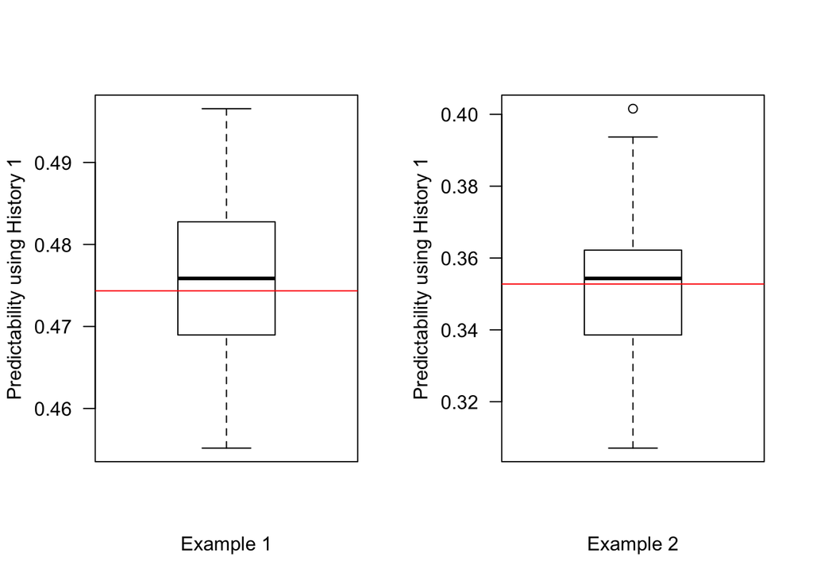

```r
# system.time(markov(breaks_example_1_chart,index_prep(breaks_example_1_chart,1),1))
# system.time(markov(breaks_example_2_chart,index_prep(breaks_example_2_chart,1),1))
#
# estimation_markov_1_example_1<- 0
# system.time(for (i in 1:1000){estimation_markov_1_example_1[i] <- markov(breaks_example_1_chart,index_prep(breaks_example_1_chart,1),1)})
# estimation_markov_1_example_2<- 0
# system.time(for (i in 1:1000){estimation_markov_1_example_2[i] <- markov(breaks_example_2_chart,index_prep(breaks_example_2_chart,1),1)})

# estimation_matrix <- data.frame(Example_1=estimation_markov_1_example_1,Example_2=estimation_markov_1_example_2,Markov=1)

#czerwona linia to średnia, a czarna to oczywiście mediana. Dlatego lepiej brać medianę.
par(mfrow=c(1,2),las=1)
boxplot(estimation_markov_1_example_1)
title(xlab = "Example 1",ylab="Predictability using History 1")
abline(h=mean(estimation_markov_1_example_1),col="red")
boxplot(estimation_markov_1_example_2)
title(xlab = "Example 2",ylab="Predictability using History 1")
abline(h=mean(estimation_markov_1_example_2),col="red")
```

# Historia 2

Czerwona linia to średnia, a czarna to mediana

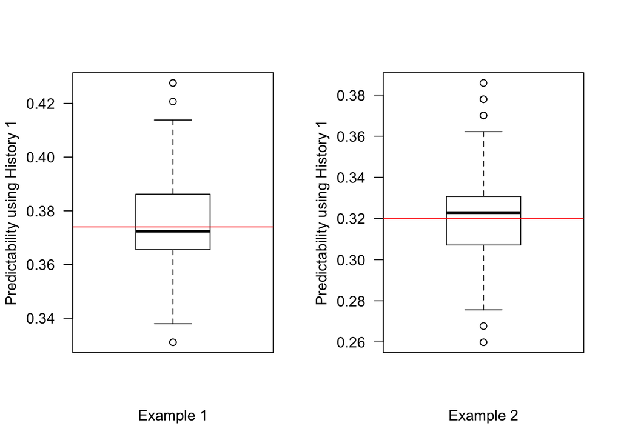

```r
# system.time(markov(breaks_example_1_chart,index_prep(breaks_example_1_chart,2),2))
# system.time(markov(breaks_example_2_chart,index_prep(breaks_example_2_chart,2),2))
#
# estimation_markov_2_example_1<- 0
# system.time(for (i in 1:1000){estimation_markov_2_example_1[i] <- markov(breaks_example_1_chart,index_prep(breaks_example_1_chart,2),2)} )
# estimation_markov_2_example_2<- 0
# system.time(for (i in 1:1000){estimation_markov_2_example_2[i] <- markov(breaks_example_2_chart,index_prep(breaks_example_2_chart,2),2)} )
#
# estimation_matrix <- rbind(estimation_matrix,data.frame(Example_1=estimation_markov_2_example_1,Example_2=estimation_markov_2_example_2,Markov=2))
# estimation_matrix

#czerwona linia to średnia, a czarna to oczywiście mediana. Dlatego lepiej brać medianę.
par(mfrow=c(1,2),las=1)
boxplot(estimation_markov_2_example_1)
title(xlab = "Example 1",ylab="Predictability using History 1")
abline(h=mean(estimation_markov_2_example_1),col="red")
boxplot(estimation_markov_2_example_2)
title(xlab = "Example 2",ylab="Predictability using History 1")
abline(h=mean(estimation_markov_2_example_2),col="red")
```

# Historia 3

Czerwona linia to średnia, a czarna to mediana

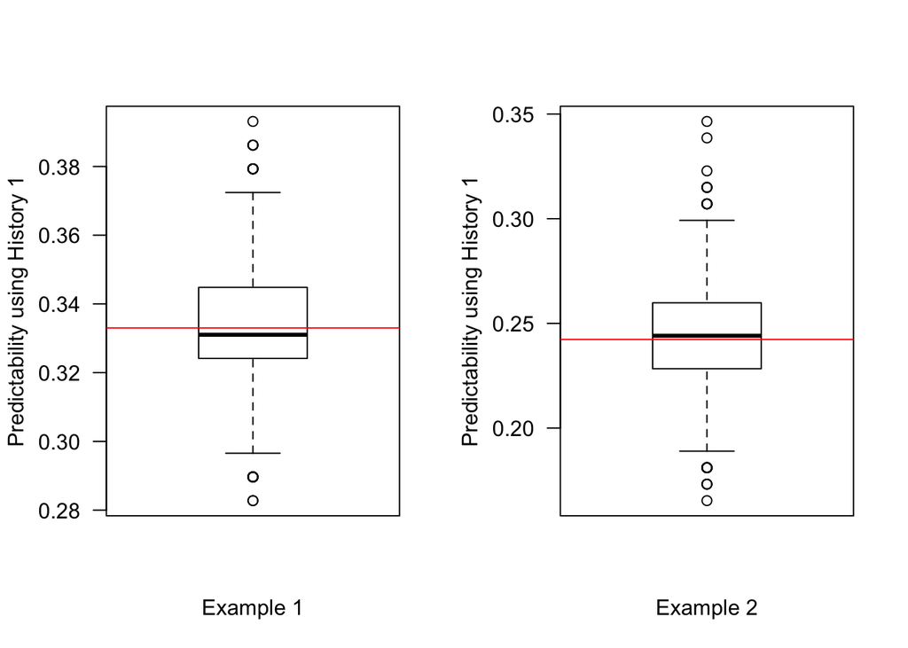

```r
# system.time(markov(breaks_example_1_chart,index_prep(breaks_example_1_chart,3),3))
# system.time(markov(breaks_example_2_chart,index_prep(breaks_example_2_chart,3),3))
#
# estimation_markov_3_example_1<- 0
# system.time(for (i in 1:1000){estimation_markov_3_example_1[i] <- markov(breaks_example_1_chart,index_prep(breaks_example_1_chart,3),3)} )
# estimation_markov_3_example_2<- 0
# system.time(for (i in 1:1000){estimation_markov_3_example_2[i] <- markov(breaks_example_2_chart,index_prep(breaks_example_2_chart,3),3)} )
#
# estimation_matrix <- rbind(estimation_matrix,data.frame(Example_1=estimation_markov_3_example_1,Example_2=estimation_markov_3_example_2,Markov=3))
# estimation_matrix

#czerwona linia to średnia, a czarna to oczywiście mediana. Dlatego lepiej brać medianę.
par(mfrow=c(1,2),las=1)
boxplot(estimation_markov_3_example_1)
title(xlab = "Example 1",ylab="Predictability using History 1")
abline(h=mean(estimation_markov_3_example_1),col="red")
boxplot(estimation_markov_3_example_2)
title(xlab = "Example 2",ylab="Predictability using History 1")
abline(h=mean(estimation_markov_3_example_2),col="red")
```

# Historia 4

Czerwona linia to średnia, a czarna to mediana

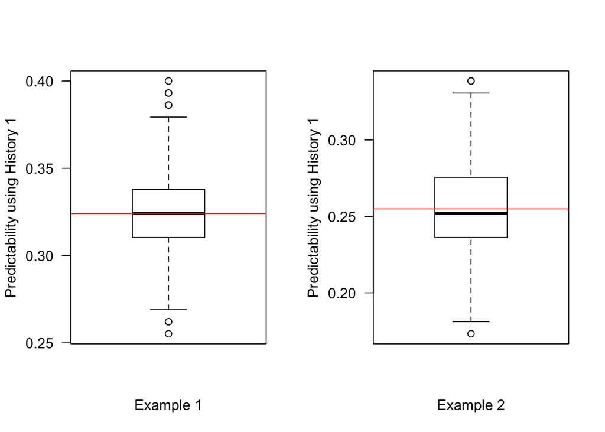

```r
# system.time(markov(breaks_example_1_chart,index_prep(breaks_example_1_chart,4),4))
# system.time(markov(breaks_example_2_chart,index_prep(breaks_example_2_chart,4),4))
#
#  estimation_markov_4_example_1<- 0
#  system.time(for (i in 1:1000){estimation_markov_4_example_1[i] <- markov(breaks_example_1_chart,index_prep(breaks_example_1_chart,1),4)} )
#  estimation_markov_4_example_2<- 0
#  system.time(for (i in 1:1000){estimation_markov_4_example_2[i] <- markov(breaks_example_2_chart,index_prep(breaks_example_2_chart,1),4)} )
#
#  estimation_matrix <- rbind(estimation_matrix,data.frame(Example_1=estimation_markov_4_example_1,Example_2=estimation_markov_4_example_2,Markov=4))
#  estimation_matrix
# #czerwona linia to średnia, a czarna to oczywiście mediana. Dlatego lepiej brać medianę.
 par(mfrow=c(1,2),las=1)
 boxplot(estimation_markov_4_example_1)
 title(xlab = "Example 1",ylab="Predictability using History 1")
 abline(h=mean(estimation_markov_4_example_1),col="red")
 boxplot(estimation_markov_4_example_2)
 title(xlab = "Example 2",ylab="Predictability using History 1")
 abline(h=mean(estimation_markov_4_example_2),col="red")
```

# Historia 5

Czerwona linia to średnia, a czarna to mediana

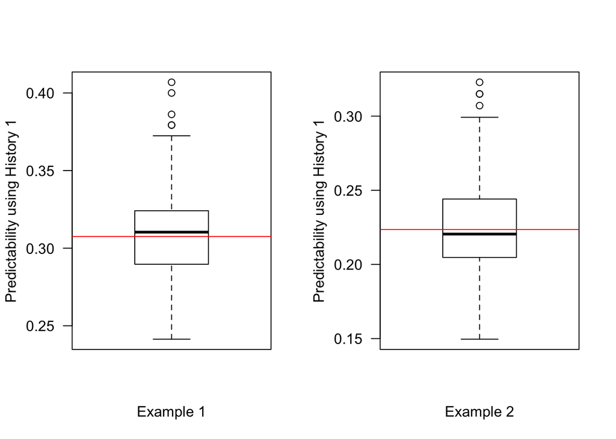

```r
# system.time(markov(breaks_example_1_chart,index_prep(breaks_example_1_chart,5),5))
# system.time(markov(breaks_example_2_chart,index_prep(breaks_example_2_chart,5),5))
#
# estimation_markov_5_example_1<- 0
# system.time(for (i in 1:1000){estimation_markov_5_example_1[i] <- (markov(breaks_example_1_chart,index_prep(breaks_example_1_chart,1),5))} )
# estimation_markov_5_example_2<- 0
# system.time(for (i in 1:1000){estimation_markov_5_example_2[i] <- (markov(breaks_example_2_chart,index_prep(breaks_example_2_chart,1),5))} )

# estimation_matrix <- rbind(estimation_matrix,data.frame(Example_1=estimation_markov_5_example_1,Example_2=estimation_markov_5_example_2,Markov=5))
# estimation_matrix
#czerwona linia to średnia, a czarna to oczywiście mediana.
par(mfrow=c(1,2),las=1)
boxplot(estimation_markov_5_example_1)
title(xlab = "Example 1",ylab="Predictability using History 1")
abline(h=mean(estimation_markov_5_example_1),col="red")
boxplot(estimation_markov_5_example_2)
title(xlab = "Example 2",ylab="Predictability using History 1")
abline(h=mean(estimation_markov_5_example_2),col="red")
```

# Symulacja

```r
# sym_markov_series <- sample(c(0,1,2,3,4,5,6),size=100000,replace = T)
# sym_example <- data.frame(Id=1:100000,gap=sym_markov_series)
# system.time(markov(sym_example,index_prep(sym_example,1),1))
```

# Podsumowanie

Zasadniczo trend jest spadkowy jeśli chodzi o historię. Można by tak pewnie w nieskończoność ale to za długo zajmie czasu. Ogólnie to była bardzo głupia funkcja, bo stała w miejscu i brała pod uwagę tylko jedną długość historii. Następna będzie brać pod uwagę różne dłgości historii i dopasowywać tę, która będzie najlepsza, żeby zmaksymalizować prawdopoodbieństwo.

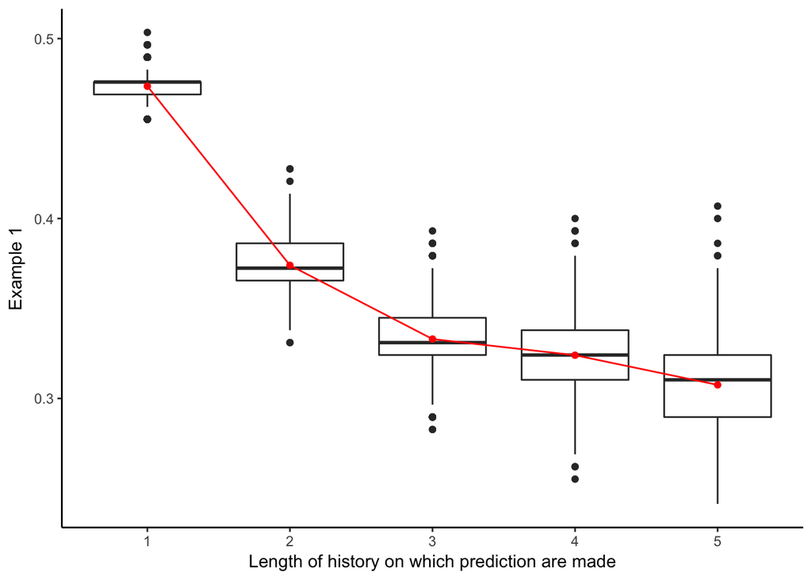

```r
table_mean_example_1 <- with(estimation_matrix,aggregate(Example_1,by=list(Markov),mean))
ggplot(data=estimation_matrix,aes(y=Example_1,x=as.factor(Markov)))+geom_boxplot()+geom_line(data=table_mean_example_1,aes(x=(Group.1),y=x),col="red")+geom_point(data=table_mean_example_1,aes(x=(Group.1),y=x),col="red")+theme_classic()+scale_y_continuous("Example 1")+scale_x_discrete("Length of history on which prediction are made")
```

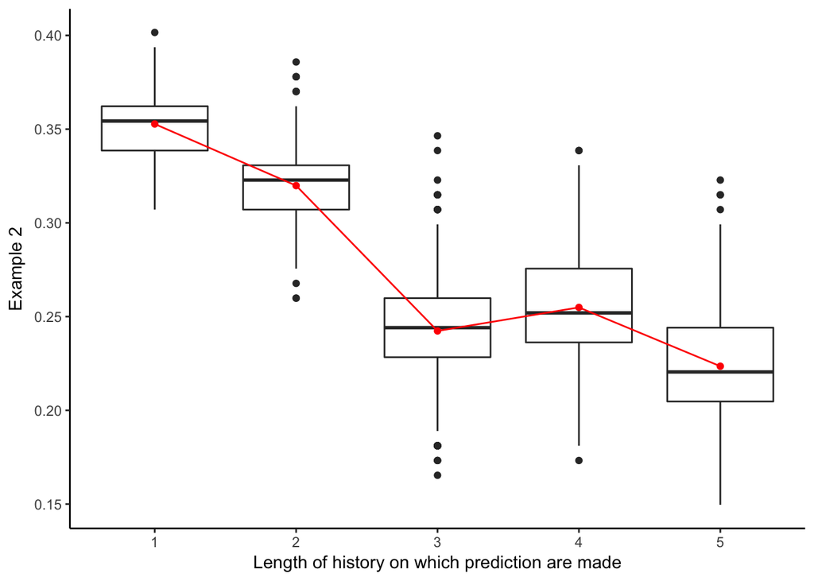

```r
table_mean_example_2 <- with(estimation_matrix,aggregate(Example_2,by=list(Markov),mean))
ggplot(data=estimation_matrix,aes(y=Example_2,x=as.factor(Markov)))+geom_boxplot()+geom_line(data=table_mean_example_2,aes(x=(Group.1),y=x),col="red")+geom_point(data=table_mean_example_2,aes(x=(Group.1),y=x),col="red")+theme_classic()+scale_y_continuous("Example 2")+scale_x_discrete("Length of history on which prediction are made")
```

## 4. Drugie podejście do ukrytych ciągów Markova.

# Funkcje

Ogólnie na razie będę używał trochę zmienionej matki wszystkich funkcji w stosunku do poprzedniego przypadku. Główna wada to oczywiście czas ale na razie nie wymyśliłem do końca jak to rozwiązać.

## 5. Trzecie podejście do ukrytych ciągów Markova.

Jeszcze nie zakodowane funkcje kroczące, czyli takie, które w oknie czasowym określają tworzą macierz transformacji dzięki czemu, jak się zmienia ciąg, to wtedy nie są zależne od początkowej części ciągu. U ludzi to miało rację bytu nie wiem jak ze strzałami neuronów.